# Problem Set 7

Author

Charlie Tran

The preferred format would be to do your work in a code chunk at the end of this document after the instructions. Use echo=TRUE for your code chunk so that your code is visible.

Do not alter the top lines between — and — except to *carefully* add your name inside the quotes.

Using your project data set, or any built in R dataset, do the following:

1. Using your chosen y (dependent) variable and one of your chosen x (explanatory) variables, perform a simple OLS regression using R. Follow these steps:

A. Load your data into a dataframe object

B. define a model object using the lm() function

```
    - The format is `model <- lm(y ~ x, data = dataframe)`
    - where:
    - y is the dependent variable name from your dataframe
    - x is the explanatory variable name from your dataframe
    - and dataframe is the name of your dataframe object
```

C. report the model statistics using the summary() function

```
    - The format is `summary(model)`
```

D. produce a model table using the stargazer() function from the stargazer library with type = “text”

```
    - The format is `stargazer(model, type = "text")`
```

2. Using the same variables, produce a scatterplot with an lm() line and 95% confidence interval. You may use the base r plot() function or the ggplot() function from Lecture 15.

```r
library(tidyverse)
library(stargazer)
real_estate <- read_csv("realtor-data.csv")
# Filter real estate in NYC and remove entire row with null in any column for a one-to-one relationship between x and y
real_estate_nyc <- real_estate %>%
        filter(state == "New York") %>%
        filter(city == "New York City") %>%
        na.omit()

# create a model of the relationship between x=acre lot size and y=price of NYC
model <- lm(price ~ acre_lot, data = real_estate_nyc)
summary(model)
```

```
Call:
lm(formula = price ~ acre_lot, data = real_estate_nyc)

Residuals:
     Min       1Q   Median       3Q      Max
-3478115 -2809826 -2024485   248008 46200384

Coefficients:
            Estimate Std. Error t value Pr(>|t|)
(Intercept)  3799905      88843  42.771   <2e-16 ***
acre_lot       -1310       8254  -0.159    0.874
---
Signif. codes:  0 '***' 0.001 '**' 0.01 '*' 0.05 '.' 0.1 ' ' 1

Residual standard error: 5158000 on 3373 degrees of freedom
Multiple R-squared:  7.467e-06, Adjusted R-squared:  -0.000289
F-statistic: 0.02519 on 1 and 3373 DF,  p-value: 0.8739
```

```r
stargazer(model, type = "text")
```

```
===============================================
                        Dependent variable:
                    ---------------------------
                               price
-----------------------------------------------
acre_lot                    -1,309.892
                            (8,253.867)

Constant                 3,799,905.000***
                           (88,842.830)

-----------------------------------------------
Observations                   3,375
R2                            0.00001
Adjusted R2                   -0.0003
Residual Std. Error  5,157,779.000 (df = 3373)
F Statistic            0.025 (df = 1; 3373)
===============================================
Note:               *p<0.1; **p<0.05; ***p<0.01
```

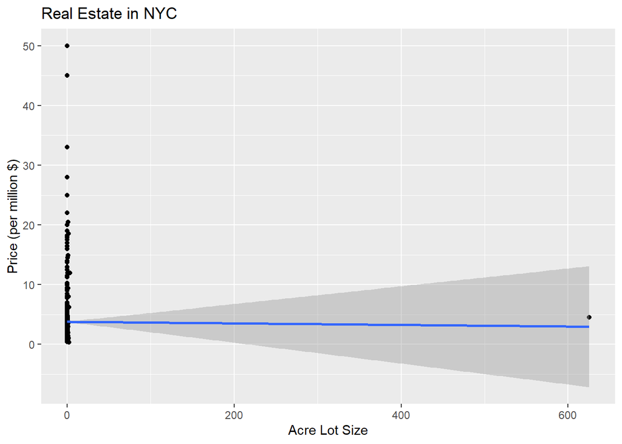

```r
real_estate_nyc %>%
        ggplot(aes(x = acre_lot, y = price/1000000)) +
        geom_point() +
        geom_smooth(method = "lm", se = TRUE) +
        labs(x ="Acre Lot Size", y ="Price (per million $)", title = "Real Estate in NYC" )
```

As seen with the value of R squared and the scatterplot, the relationship and correlation between acre lot size and price is very small and unexpected. This is because of the high variability of price at smaller acre lot size. It is also important to note that the p-value of 0.874 shows that there is not statistical significant between acre lot size and price of real estate in NYC adn thus the unreliability of the regression model. Below is a modified scatterplot for observation of the variability of real estate of less than or equal to one acre.

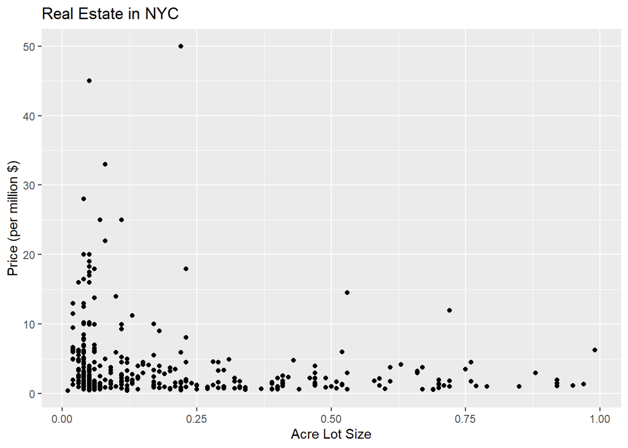

```r
real_estate_nyc %>%
        filter(acre_lot <= 1) %>%
        ggplot(aes(x = acre_lot, y = price/1000000)) +
        geom_point() +
        labs(x ="Acre Lot Size", y ="Price (per million $)", title = "Real Estate in NYC" )
```